Michael Clougher  
605.745  
Final Code Submission

# Fuzzy Logic in Classification of Tumor Images

This paper will seek to utilize fuzzy logic to classify images of tumors as either benign or malignant using data obtained from the UCI Machine Learning Repository.

```python
import pandas as pd
import numpy as np
from sklearn.datasets import load_breast_cancer
import matplotlib.pyplot as plt
import seaborn as sns
sns.set(style="whitegrid")
mainColor = 'goldenrod'
secondColor = 'midnightblue'
```

Let's take a broad overview of the data.

```python
# https://stackoverflow.com/questions/38105539/how-to-convert-a-scikit-learn-dataset-to-a-pandas-dataset/46379878#46379878
cancer_data = load_breast_cancer()
data = pd.DataFrame(cancer_data.data,columns=cancer_data.feature_names)
data['benign'] = pd.Series(cancer_data.target) #1 for benign, 0 for malignant
data.head()
```

|  | mean radius | mean texture | mean perimeter | mean area | mean smoothness | mean compactness | mean concavity | mean concave points | mean symmetry | mean fractal dimension | ... | worst texture | worst perimeter | worst area | worst smoothness | worst compactness | worst concavity | worst concave points | worst symmetry | worst fractal dimension | benign |
| --- | --- | --- | --- | --- | --- | --- | --- | --- | --- | --- | --- | --- | --- | --- | --- | --- | --- | --- | --- | --- | --- |
| 0 | 17.99 | 10.38 | 122.80 | 1001.0 | 0.11840 | 0.27760 | 0.3001 | 0.14710 | 0.2419 | 0.07871 | ... | 17.33 | 184.60 | 2019.0 | 0.1622 | 0.6656 | 0.7119 | 0.2654 | 0.4601 | 0.11890 | 0 |
| 1 | 20.57 | 17.77 | 132.90 | 1326.0 | 0.08474 | 0.07864 | 0.0869 | 0.07017 | 0.1812 | 0.05667 | ... | 23.41 | 158.80 | 1956.0 | 0.1238 | 0.1866 | 0.2416 | 0.1860 | 0.2750 | 0.08902 | 0 |
| 2 | 19.69 | 21.25 | 130.00 | 1203.0 | 0.10960 | 0.15990 | 0.1974 | 0.12790 | 0.2069 | 0.05999 | ... | 25.53 | 152.50 | 1709.0 | 0.1444 | 0.4245 | 0.4504 | 0.2430 | 0.3613 | 0.08758 | 0 |
| 3 | 11.42 | 20.38 | 77.58 | 386.1 | 0.14250 | 0.28390 | 0.2414 | 0.10520 | 0.2597 | 0.09744 | ... | 26.50 | 98.87 | 567.7 | 0.2098 | 0.8663 | 0.6869 | 0.2575 | 0.6638 | 0.17300 | 0 |
| 4 | 20.29 | 14.34 | 135.10 | 1297.0 | 0.10030 | 0.13280 | 0.1980 | 0.10430 | 0.1809 | 0.05883 | ... | 16.67 | 152.20 | 1575.0 | 0.1374 | 0.2050 | 0.4000 | 0.1625 | 0.2364 | 0.07678 | 0 |

5 rows × 31 columns

```python
for i, col in enumerate(data.columns):
    print(i+1,col)
```

```
1 mean radius
2 mean texture
3 mean perimeter
4 mean area
5 mean smoothness
6 mean compactness
7 mean concavity
8 mean concave points
9 mean symmetry
10 mean fractal dimension
11 radius error
12 texture error
13 perimeter error
14 area error
15 smoothness error
```

[output cut: 16 more lines]

## EDA

```python
def histogram(data,column,bins=50,weights=None,lines=[]):
    figure = plt.figure(figsize=(10, 6))
    axes = figure.add_subplot(1, 1, 1)

    axes.set_xlabel(column, fontsize=20)
    axes.set_ylabel("Count", fontsize=20)

    chart = axes.hist(data[column], bins=bins, color=mainColor,ec='black',weights=weights)

    max_y = max(chart[0])
    axes.vlines(lines,0,max_y+2,color=secondColor,lw=4)

    axes.set_title("Histogram of " + column + "; " + str(bins) + " bins", fontsize=25)
    axes.grid(zorder=0)

    plt.show()
    plt.close()
```

### Mean Radius

According to the documentation for this dataset, the radius is (unsurprisingly) the "mean of distances from center to points on the perimeter".

```python
data['mean radius'].describe()
```

```
count    569.000000
mean      14.127292
std        3.524049
min        6.981000
25%       11.700000
50%       13.370000
75%       15.780000
max       28.110000
Name: mean radius, dtype: float64
```

Let's see what this distribution actually looks like:

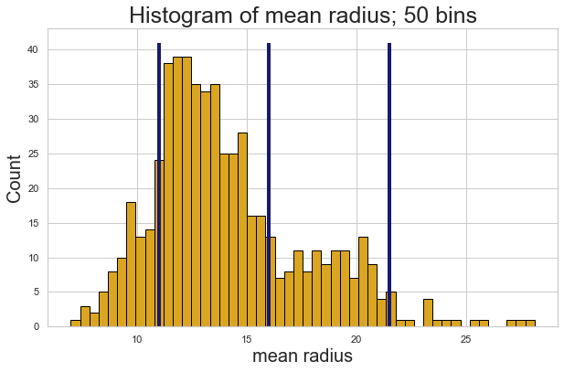

```python
histogram(data,"mean radius", lines=[11,16,21.5])
```

Some type of skewed normal distribution could be a reasonable approximation for these values.

### Texture

The texture here is the standard deviation of the gray scale values.

```python
data['mean texture'].describe()
```

```
count    569.000000
mean      19.289649
std        4.301036
min        9.710000
25%       16.170000
50%       18.840000
75%       21.800000
max       39.280000
Name: mean texture, dtype: float64
```

Let's visualize:

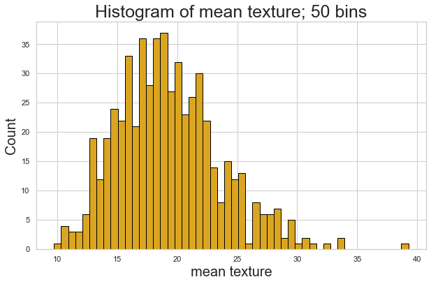

```python
histogram(data,"mean texture")
```

This chart looks similar to the previous one.

### Mean Perimeter

The perimeter here is fairly self explanatory.

```python
data['mean perimeter'].describe()
```

```
count    569.000000
mean      91.969033
std       24.298981
min       43.790000
25%       75.170000
50%       86.240000
75%      104.100000
max      188.500000
Name: mean perimeter, dtype: float64
```

Again, we want to see this as a chart:

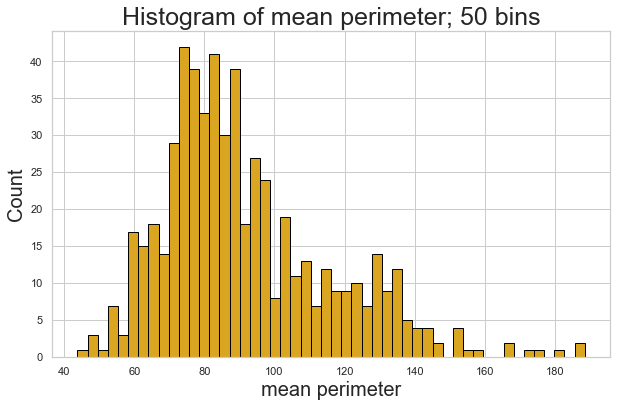

```python
histogram(data,"mean perimeter")
```

Unsurprisingly, these variables have all been describing various aspects of the physical size of the tumor, and so it makes sense that they would have similar distributions.

### Mean Area

The area here is again self explanatory.

```python
data['mean area'].describe()
```

```
count     569.000000
mean      654.889104
std       351.914129
min       143.500000
25%       420.300000
50%       551.100000
75%       782.700000
max      2501.000000
Name: mean area, dtype: float64
```

Visualizing:

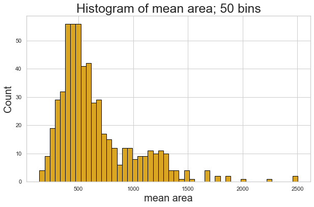

```python
histogram(data,"mean area")
```

There are a few outliers here and it might be worth exploring later on if there is any potential that they are errors.

### Mean Smoothness

The smoothness here describes the local variation in radius lengths.

```python
data['mean smoothness'].describe()
```

```
count    569.000000
mean       0.096360
std        0.014064
min        0.052630
25%        0.086370
50%        0.095870
75%        0.105300
max        0.163400
Name: mean smoothness, dtype: float64
```

This data might start to look a bit different as it is no longer about the size of the tumor, but rather the shape.

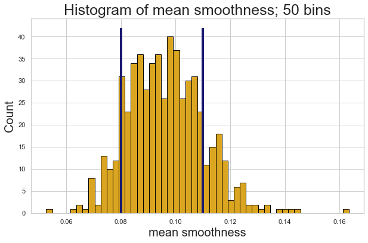

```python
histogram(data,"mean smoothness", lines=[0.08,0.11])
```

This data now looks like a more standard bell curve.

### Mean Compactness

The compactness column is calculated from modifying two other variables observed earlier, where

compactness = (perimeter^2) / (area - 1)

```python
data['mean compactness'].describe()
```

```
count    569.000000
mean       0.104341
std        0.052813
min        0.019380
25%        0.064920
50%        0.092630
75%        0.130400
max        0.345400
Name: mean compactness, dtype: float64
```

Visualizing:

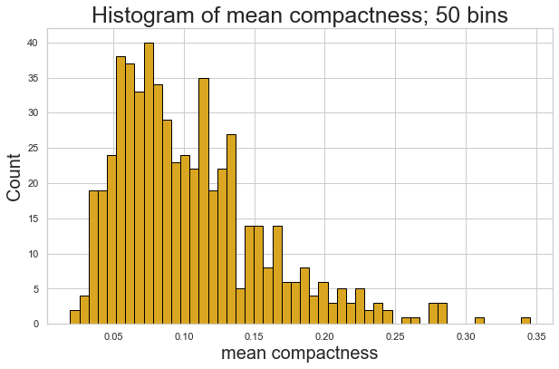

```python
histogram(data,"mean compactness")
```

This shape is unsurprising given what we saw from these columns earlier.

### Mean Concavity

The documentation describes the concavity as "severity of concave portions of the contour".

```python
data['mean concavity'].describe()
```

```
count    569.000000
mean       0.088799
std        0.079720
min        0.000000
25%        0.029560
50%        0.061540
75%        0.130700
max        0.426800
Name: mean concavity, dtype: float64
```

How will this distribution differ?

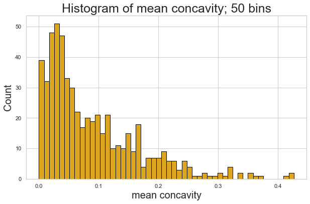

```python
histogram(data,"mean concavity")
```

This seems to resemble more of either an exponential distribution or perhaps a truncated normal.

### Mean Concave Points

This variable describes the number of concave portions of the contour.

```python
data['mean concave points'].describe()
```

```
count    569.000000
mean       0.048919
std        0.038803
min        0.000000
25%        0.020310
50%        0.033500
75%        0.074000
max        0.201200
Name: mean concave points, dtype: float64
```

Again, we want to visualize:

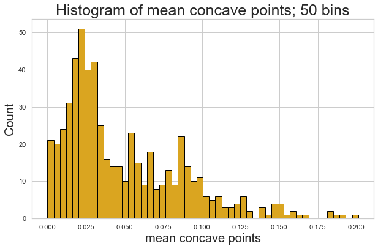

```python
histogram(data,"mean concave points")
```

We see a similar shape as we have been seeing.

### Mean Symmetry

This variable is a measure of how symmetrical a tumor is, yet it is not entirely clear how it was measured.

```python
data['mean symmetry'].describe()
```

```
count    569.000000
mean       0.181162
std        0.027414
min        0.106000
25%        0.161900
50%        0.179200
75%        0.195700
max        0.304000
Name: mean symmetry, dtype: float64
```

Visualizing it:

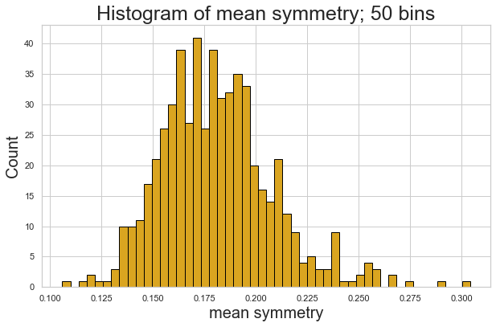

```python
histogram(data,"mean symmetry")
```

We see a fairly symmetrical chart here.

### Mean Fractal Dimension

This variable measures the complexity around the perimeter of the tumor.

```python
data['mean fractal dimension'].describe()
```

```
count    569.000000
mean       0.062798
std        0.007060
min        0.049960
25%        0.057700
50%        0.061540
75%        0.066120
max        0.097440
Name: mean fractal dimension, dtype: float64
```

Seeing this data:

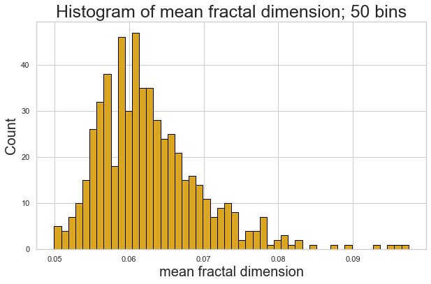

```python
histogram(data,"mean fractal dimension")
```

This variable uses a "coastline approximation" and so it unsurprisingly looks markedly similar to our perimeter chart.

## Benign / Malignant

We finally move on to our target variable: benign.

```python
data['benign'].value_counts()
```

```
1    357
0    212
Name: benign, dtype: int64
```

Values of "1" represent benign tumors, while "0" values are malignant.

## Pairwise EDA

Let's now look at how each of these variables looks when grouping into benign and malignant categories.

```python
def pairwiseEDA(feature):

    fig, (ax1, ax2) = plt.subplots(figsize=(20,6),ncols=2, sharex=True, sharey=True)

    x1=data.groupby('benign')[feature].get_group(0)
    x2=data.groupby('benign')[feature].get_group(1)

    ax1.hist(x1, color=mainColor,ec='black',zorder=2,bins=40)
    ax1.set_xlabel(feature, fontsize=20)
    ax1.set_ylabel("Number", fontsize=20)
    ax1.set_title("Malignant", fontsize=25)
    ax1.grid(zorder=0)

    ax2.hist(x2, color=mainColor,ec='black',zorder=2,bins=40)
    ax2.set_xlabel(feature, fontsize=20)
    ax2.set_title("Benign", fontsize=25)
    ax2.grid(zorder=0)

    plt.show()
    plt.close()
```

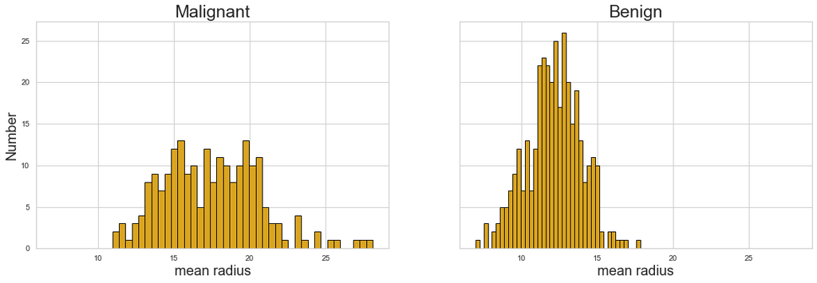

```python
pairwiseEDA('mean radius')
```

It seems that benign tumors do not get very large.

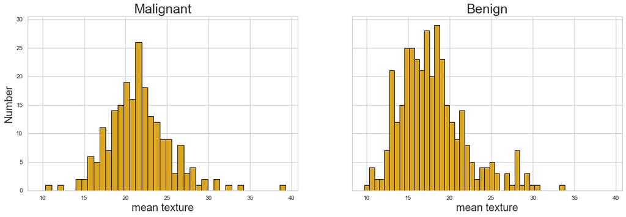

```python
pairwiseEDA('mean texture')
```

There is not much distinction we can determine from texture.

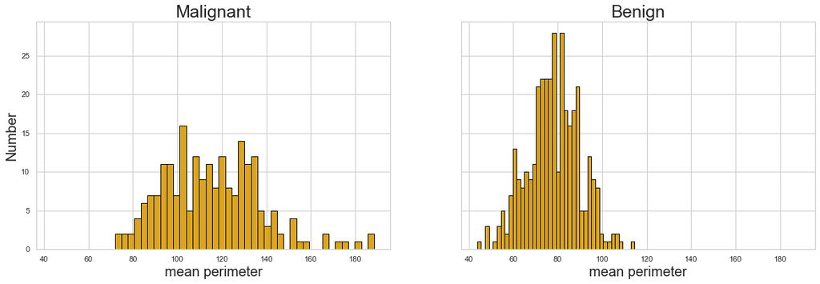

```python
pairwiseEDA('mean perimeter')
```

We see the same pattern here as radius

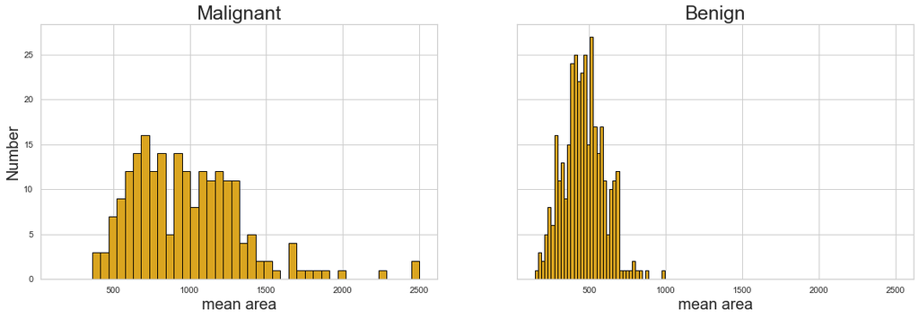

```python
pairwiseEDA('mean area')
```

Again, the same pattern here as radius.

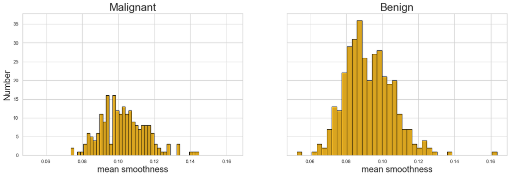

```python
pairwiseEDA('mean smoothness')
```

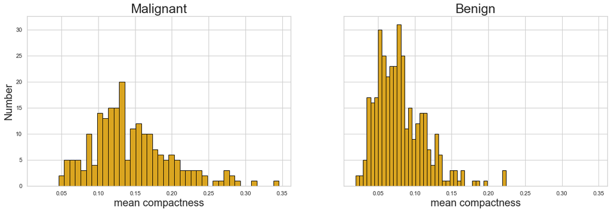

```python
pairwiseEDA('mean compactness')
```

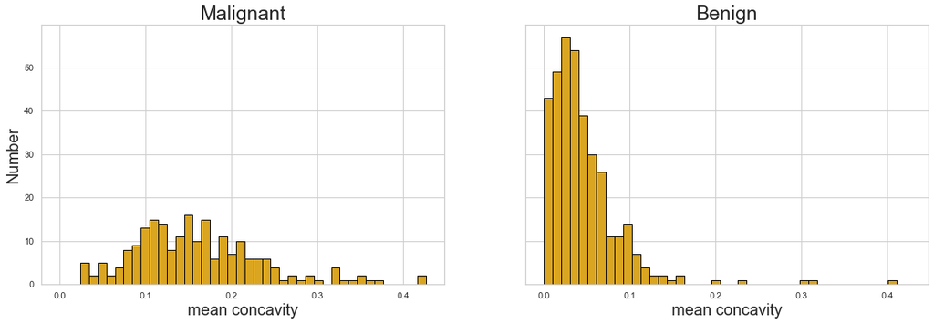

```python
pairwiseEDA('mean concavity')
```

Here it seems that lower concavity tumors are very likely to be benign.

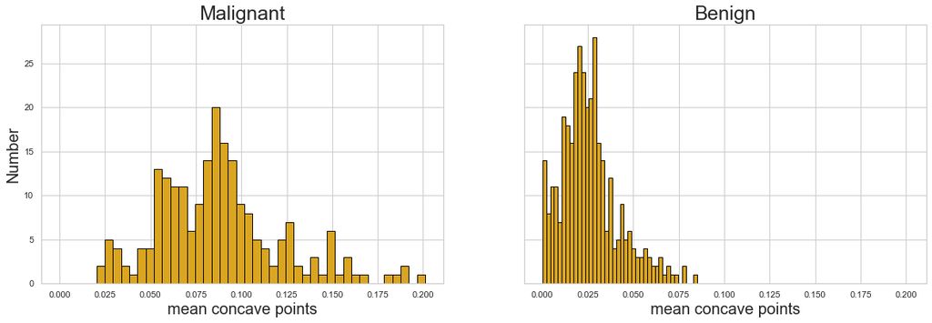

```python
pairwiseEDA('mean concave points')
```

We see a similar pattern to compactness.

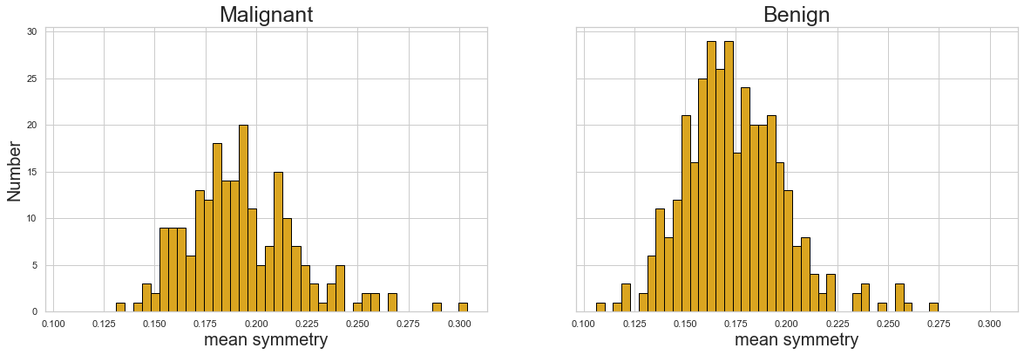

```python
pairwiseEDA('mean symmetry')
```

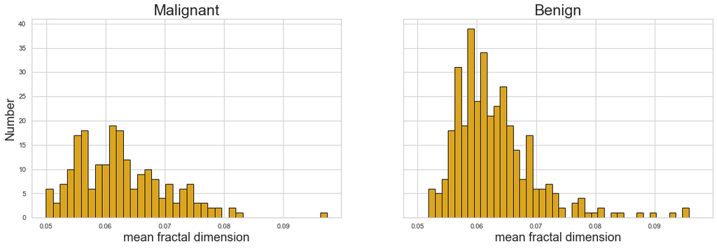

```python
pairwiseEDA('mean fractal dimension')
```

## Fuzzification

We now begin the process of fuzzifying our features to use in our model. The following *fuzzify* function takes the column given in the data and creates fuzzy classes with the names provided such as "small", "medium", or "large". We have chosen to create all fuzzy classes with trapezoidal shapes. Our function will take any number of class names (minimum of 2), and create evenly distributed classes across the range of data. We will also create new feature columns in our dataframe, and plot the classes on a chart.

```python
def plotFuzz(divisions, point, point_Y_vals, attribute_name, labels):

    figure = plt.figure(figsize=(10, 6))
    axes = figure.add_subplot(1, 1, 1)

    first_class_X = [divisions[0],divisions[1],divisions[2]]
    last_class_X = [divisions[-3],divisions[-2],divisions[-1]]
    first_class_Y = [1,1,0]
    last_class_Y = [0,1,1]

    position = 1
    middle_classes = []
    for _ in range(int(len(divisions)/2)-2): #for the middle classes
        middle_class_X = [divisions[position],divisions[position+1],divisions[position+2],divisions[position+3]]
        middle_class_Y = [0,1,1,0]
        middle_classes.append([middle_class_X,middle_class_Y])
        position+=2

    lw=4
    plt.plot(first_class_X,first_class_Y,lw=lw,label="Class: {}".format(labels[0]))
    for label_index, middle_class in enumerate(middle_classes): #different shape than first and last classes
        plt.plot(middle_class[0],middle_class[1],lw=lw,label="Class: {}".format(labels[label_index+1]))
    plt.plot(last_class_X,last_class_Y,lw=lw,label="Class: {}".format(labels[-1]))

    plt.plot(point,point_Y_vals[0],'ko',label="First entry: {}".format(point))
    plt.plot(point,point_Y_vals[1],'ko')

    axes.set_xlabel(attribute_name, fontsize=20)
    axes.set_ylabel("Membership Value", fontsize=20)
    axes.set_title("Fuzzy Membership Classes for {}".format(attribute_name), fontsize=25)

    plt.legend(bbox_to_anchor=(1.05, 1), loc='upper left', prop={'size': 15})
    plt.show()
    plt.close()
```

```python
import bisect
import math

def fuzzify(feature_values, class_names):
    # Here trapezoidal shape is assumed, values in no more than two classes
    classes_length = len(class_names) #can create any fuzzy number of fuzzy classes
    top_trap_length = 1/(classes_length + (classes_length-1)/2) #length of top trapezoidal shape
    side_trap_length = top_trap_length/2 #length of each diagonal

    x_axis_divisions = [0] #this will hold a list of all points on x axis where a new class may start to appear
    x_axis_position = 0 #pointer

    for i in range(classes_length-1): # "walk" along x axis creating division points from 0 to 1
        x_axis_position += top_trap_length
        x_axis_divisions.append(x_axis_position)
        x_axis_position += side_trap_length
        x_axis_divisions.append(x_axis_position)
    x_axis_divisions.append(1) #to avoid rounding error we explicitly assign this last point

    feature_range = max(feature_values) - min(feature_values)
    x_axis_divisions = [x*feature_range+min(feature_values) for x in x_axis_divisions] #scale to feature range

    for df_position, value in enumerate(feature_values): #for each value in df, determine membership value in each class

        index_div_position = bisect.bisect_left(x_axis_divisions, value) #find where this value would fall on the fuzzy x axis

        membership_values = {}
        if(index_div_position%2==0):
            low_class_bound = x_axis_divisions[index_div_position-1]
            high_class_bound = x_axis_divisions[index_div_position]
            distance = high_class_bound - low_class_bound

            high_membership = (value-low_class_bound)/distance
            low_membership = 1 - high_membership

            lower_class = class_names[math.floor(index_div_position/2)-1]
            membership_values[lower_class] = low_membership

            upper_class = class_names[math.floor(index_div_position/2)]
            membership_values[upper_class] = high_membership

            if value==min(feature_values): #for plotting, special case of bisect
                low_membership = 1

        else:
            low_membership = 1
            high_membership = 1

            upper_class = class_names[math.floor(index_div_position/2)]
            membership_values[upper_class] = high_membership

        for class_name in class_names:
            if membership_values.get(class_name) is not None:
                data.at[df_position, "Fuzzy {} class: {}".format(feature_values.name,class_name)] = membership_values.get(class_name)
            else:
                data.at[df_position, "Fuzzy {} class: {}".format(feature_values.name,class_name)] = 0

        if(df_position==0): #plot first point
            plotFuzz(x_axis_divisions, value, [low_membership, high_membership], feature_values.name, class_names)

    return x_axis_divisions
```

Let's try fuzzifying our radius and concavity results and use these to create rules. These two features seemed to most distinctly show differences in benign vs malignancy during EDA.

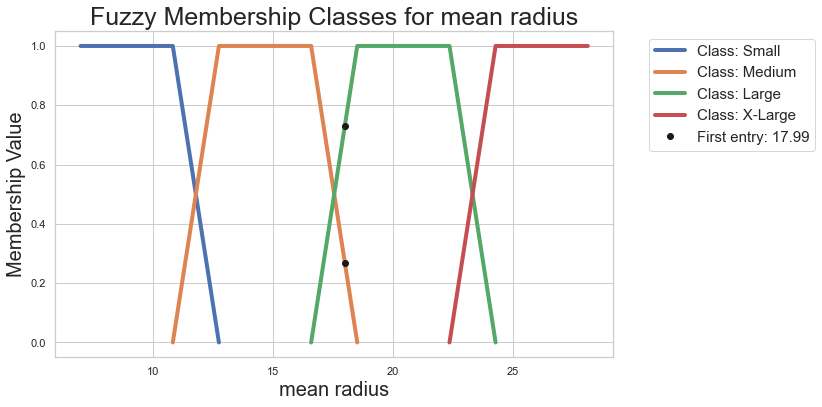

```python
fuzzify(data['mean radius'], ['Small','Medium','Large','X-Large']);
```

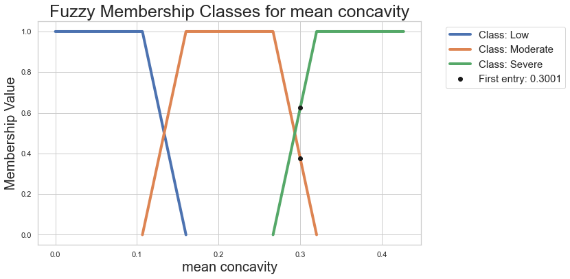

```python
fuzzify(data['mean concavity'], ['Low','Moderate','Severe']);
```

```python
data.head()
```

|  | mean radius | mean texture | mean perimeter | mean area | mean smoothness | mean compactness | mean concavity | mean concave points | mean symmetry | mean fractal dimension | ... | worst symmetry | worst fractal dimension | benign | Fuzzy mean radius class: Small | Fuzzy mean radius class: Medium | Fuzzy mean radius class: Large | Fuzzy mean radius class: X-Large | Fuzzy mean concavity class: Low | Fuzzy mean concavity class: Moderate | Fuzzy mean concavity class: Severe |
| --- | --- | --- | --- | --- | --- | --- | --- | --- | --- | --- | --- | --- | --- | --- | --- | --- | --- | --- | --- | --- | --- |
| 0 | 17.99 | 10.38 | 122.80 | 1001.0 | 0.11840 | 0.27760 | 0.3001 | 0.14710 | 0.2419 | 0.07871 | ... | 0.4601 | 0.11890 | 0 | 0.000000 | 0.268588 | 0.731412 | 0.0 | 0.0 | 0.374883 | 0.625117 |
| 1 | 20.57 | 17.77 | 132.90 | 1326.0 | 0.08474 | 0.07864 | 0.0869 | 0.07017 | 0.1812 | 0.05667 | ... | 0.2750 | 0.08902 | 0 | 0.000000 | 0.000000 | 1.000000 | 0.0 | 1.0 | 0.000000 | 0.000000 |
| 2 | 19.69 | 21.25 | 130.00 | 1203.0 | 0.10960 | 0.15990 | 0.1974 | 0.12790 | 0.2069 | 0.05999 | ... | 0.3613 | 0.08758 | 0 | 0.000000 | 0.000000 | 1.000000 | 0.0 | 0.0 | 1.000000 | 0.000000 |
| 3 | 11.42 | 20.38 | 77.58 | 386.1 | 0.14250 | 0.28390 | 0.2414 | 0.10520 | 0.2597 | 0.09744 | ... | 0.6638 | 0.17300 | 0 | 0.689006 | 0.310994 | 0.000000 | 0.0 | 0.0 | 1.000000 | 0.000000 |
| 4 | 20.29 | 14.34 | 135.10 | 1297.0 | 0.10030 | 0.13280 | 0.1980 | 0.10430 | 0.1809 | 0.05883 | ... | 0.2364 | 0.07678 | 0 | 0.000000 | 0.000000 | 1.000000 | 0.0 | 0.0 | 1.000000 | 0.000000 |

5 rows × 38 columns

We see some new column features have been added to our dataframe.

## Evaluation & Results

Let's try to build some rules now utilizing radius and concavity:

```python
def defuzzifyTest():

    #sum membership values and weight each component of rule evenly
    rule1 = data["Fuzzy mean radius class: X-Large"]
    rule2 = data["Fuzzy mean radius class: Small"]
    rule3 = (data["Fuzzy mean radius class: Large"] + data["Fuzzy mean radius class: Medium"]
            + data["Fuzzy mean concavity class: Low"]) / 3
    rule4 = (data["Fuzzy mean radius class: Large"] + data["Fuzzy mean radius class: Medium"]
            + data["Fuzzy mean concavity class: Moderate"] + data["Fuzzy mean concavity class: Severe"]) / 4

    #weight "benign" and "malignant" rules evenly
    data["fuzzy_output_malignant"] = (rule1 + rule4 )/2
    data["fuzzy_output_benign"] = (rule2 + rule3 )/2

    #majority will be winner
    data['crisp_output_test'] = data.apply(lambda x : 1 if x['fuzzy_output_malignant'] > x['fuzzy_output_benign'] else 0, axis=1)
```

```python
data['malignant'] = 1 - data['benign']
defuzzifyTest()
```

```python
def evaluateMetrics(predictions,actuals):

    #Find true/false positives/negatives

    true_positives = 0
    true_negatives = 0
    false_positives = 0
    false_negatives = 0

    for index,prediction in enumerate(predictions):
        if(actuals[index] == prediction):
            if(prediction == 1):
                true_positives += 1
            else:
                true_negatives +=1
        elif(prediction == 1):
            false_positives += 1
        else:
            false_negatives += 1

    return true_positives, true_negatives, false_positives, false_negatives
```

```python
fuzzy_predictions = data["crisp_output_test"]
actuals = data["malignant"]
fuzzy_tp, fuzzy_tn, fuzzy_fp, fuzzy_fn = evaluateMetrics(fuzzy_predictions,actuals)
```

```python
def get_precision(tp,tn,fp,fn):
    return tp/(tp+fp)
```

```python
def get_sensitivity(tp,tn,fp,fn):
    return tp/(tp+fn)
```

```python
def get_specificity(tp,tn,fp,fn):
    return tn/(tn+fn)
```

```python
fuzzy_precision = get_precision(fuzzy_tp, fuzzy_tn, fuzzy_fp, fuzzy_fn)
fuzzy_precision
```

```
0.9827586206896551
```

```python
fuzzy_sensitivity = get_sensitivity(fuzzy_tp, fuzzy_tn, fuzzy_fp, fuzzy_fn)
fuzzy_sensitivity
```

```
0.5377358490566038
```

```python
fuzzy_specificity = get_specificity(fuzzy_tp, fuzzy_tn, fuzzy_fp, fuzzy_fn)
fuzzy_specificity
```

```
0.7836644591611479
```

We see quite promising results from our precision metric, however, our sensitivity is quite low. After much experimentation, it was found that substituting smoothness for concavity provided a fair sensitivity value, (at the cost of some precision). We now demonstrate our final model:

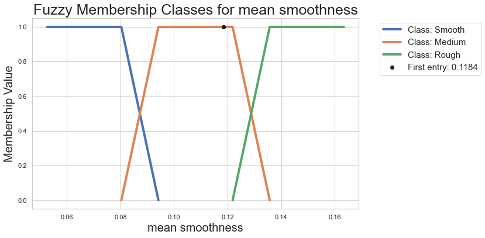

```python
fuzzify(data['mean smoothness'], ['Smooth','Medium','Rough']);
```

### Rules:

IF (radius is X-large) THEN tumor is malignant  
IF (radius is small) THEN tumor is benign  
IF (radius is large OR medium) AND (smoothness is smooth) THEN tumor is benign  
IF (radius is large OR medium) AND (smoothness is medium or rough) THEN tumor is malignant

```python
def defuzzify():

    #sum membership values and weight each component of rule evenly
    rule1 = data["Fuzzy mean radius class: X-Large"]
    rule2 = data["Fuzzy mean radius class: Small"]
    rule3 = (data["Fuzzy mean radius class: Large"] + data["Fuzzy mean radius class: Medium"]
            + data["Fuzzy mean smoothness class: Smooth"]) / 3
    rule4 = (data["Fuzzy mean radius class: Large"] + data["Fuzzy mean radius class: Medium"]
            + data["Fuzzy mean smoothness class: Medium"] + data["Fuzzy mean smoothness class: Rough"]) / 4

    #weight "benign" and "malignant" rules evenly
    data["fuzzy_output_malignant"] = (rule1 + rule4 )/2
    data["fuzzy_output_benign"] = (rule2 + rule3 )/2

    #majority will be winner
    data['crisp_output'] = data.apply(lambda x : 1 if x['fuzzy_output_malignant'] > x['fuzzy_output_benign'] else 0, axis=1)
```

```python
defuzzify()
display = data[['mean radius', "Fuzzy mean radius class: Small", "Fuzzy mean radius class: Medium", 'mean smoothness', "Fuzzy mean smoothness class: Smooth", "Fuzzy mean smoothness class: Medium", 'fuzzy_output_malignant', 'fuzzy_output_benign', 'crisp_output', 'malignant']]

seed=0
found=False
while found is False:
    np.random.seed(seed)
    if display.sample(frac=.02).iloc[-2].name==475: # 475 is a good example to highlight
        found=True
    seed+=1
```

```python
np.random.seed(seed-1)
display.sample(frac=.02)
```

|  | mean radius | Fuzzy mean radius class: Small | Fuzzy mean radius class: Medium | mean smoothness | Fuzzy mean smoothness class: Smooth | Fuzzy mean smoothness class: Medium | fuzzy_output_malignant | fuzzy_output_benign | crisp_output | malignant |
| --- | --- | --- | --- | --- | --- | --- | --- | --- | --- | --- |
| 327 | 12.03 | 0.371433 | 0.628567 | 0.07683 | 1.000000 | 0.000000 | 0.078571 | 0.457144 | 0 | 0 |
| 497 | 12.47 | 0.142364 | 0.857636 | 0.08928 | 0.353074 | 0.646926 | 0.188070 | 0.272967 | 0 | 0 |
| 132 | 16.16 | 0.000000 | 1.000000 | 0.10080 | 0.000000 | 1.000000 | 0.250000 | 0.166667 | 1 | 1 |
| 32 | 17.02 | 0.000000 | 0.773581 | 0.11970 | 0.000000 | 1.000000 | 0.250000 | 0.166667 | 1 | 1 |
| 306 | 13.20 | 0.000000 | 1.000000 | 0.08511 | 0.654239 | 0.345761 | 0.168220 | 0.275706 | 0 | 0 |
| 134 | 18.45 | 0.000000 | 0.029107 | 0.09430 | 0.000000 | 1.000000 | 0.250000 | 0.166667 | 1 | 1 |
| 381 | 11.04 | 0.886838 | 0.113162 | 0.07987 | 1.000000 | 0.000000 | 0.014145 | 0.628946 | 0 | 0 |
| 484 | 15.73 | 0.000000 | 1.000000 | 0.10430 | 0.000000 | 1.000000 | 0.250000 | 0.166667 | 1 | 0 |
| 25 | 17.14 | 0.000000 | 0.711108 | 0.11860 | 0.000000 | 1.000000 | 0.250000 | 0.166667 | 1 | 1 |
| 475 | 12.83 | 0.000000 | 1.000000 | 0.09040 | 0.272186 | 0.727814 | 0.215977 | 0.212031 | 1 | 0 |
| 65 | 14.78 | 0.000000 | 1.000000 | 0.11720 | 0.000000 | 1.000000 | 0.250000 | 0.166667 | 1 | 1 |

The above shows a sample of our predictions in the "crisp_output" column versus the actual value in the "malignant" column.

```python
fuzzy_predictions = data["crisp_output"]
actuals = data["malignant"]
fuzzy_tp, fuzzy_tn, fuzzy_fp, fuzzy_fn = evaluateMetrics(fuzzy_predictions,actuals)
```

```python
fuzzy_precision = get_precision(fuzzy_tp, fuzzy_tn, fuzzy_fp, fuzzy_fn)
fuzzy_precision
```

```
0.7213114754098361
```

```python
fuzzy_sensitivity = get_sensitivity(fuzzy_tp, fuzzy_tn, fuzzy_fp, fuzzy_fn)
fuzzy_sensitivity
```

```
0.8301886792452831
```

```python
fuzzy_specificity = get_specificity(fuzzy_tp, fuzzy_tn, fuzzy_fp, fuzzy_fn)
fuzzy_specificity
```

```
0.8892307692307693
```

We see our preliminary results above, and as we can see we have greatly increased our sensitivity, albeit at the cost of precision. We now want to accomplish two things: compare these results to a more standard baseline model and validate these results as more robust by simulating the experiments many times using the bootstrap method.

## Comparison to Logistic Regression Model

We choose to utilize the logistic regression model from *sklearn*. Though not shown here, many sets of features were tried and the same features used in our fuzzy model "mean radius" and "mean smoothness" were shown to provide either the best result within a range of 0.1 or came at the cost of worsening another metric. For convenience and ease of comparison, we therefore ultimately chose these features to train our regression model. We also evaluate our fuzzy bootstrap metrics on the same test set for each iteration of our simulation to ensure comparable results.

```python
from sklearn.linear_model import LogisticRegression
```

```python
from sklearn.model_selection import train_test_split
num_bootstrap_samples = 100

features = ['mean radius', 'mean smoothness'] #logistic regression featues
feature_x_vals = [np.array(data[feature]).reshape(-1,1) for feature in features]

X = np.concatenate(feature_x_vals,axis=1)
y = data['malignant'].values

#fuzzy bootstrap metrics, will have 100 values by end
fuzzy_bs_precisions = []
fuzzy_bs_sensitivities = []
fuzzy_bs_specificities = []

#fuzzy log regression metrics, will have 100 values by end
log_precisions = []
log_sensitivities = []
log_specificities = []

reg = LogisticRegression() #create logistic regressor

for boostrap_sample in range(num_bootstrap_samples):
    fuzzy_predictions_boostrap = []

    x_train, x_test, y_train, y_test = train_test_split(X, y, test_size=0.4, random_state=boostrap_sample) #create train and test data

    for x in range(len(x_test)):
        row = data[(data[features[0]]==x_test[x][0]) & (data[features[1]]==x_test[x][1])] #find the row being tested in log regressor
        crisp = row['crisp_output'].values[0] #find the crisp output determined from the fuzzy rules here
        fuzzy_predictions_boostrap.append(crisp) #append to fuzzy results

    fuzzy_bs_tp, fuzzy_bs_tn, fuzzy_bs_fp, fuzzy_bs_fn = evaluateMetrics(fuzzy_predictions_boostrap,y_test)

    fuzzy_bs_precision = get_precision(fuzzy_bs_tp, fuzzy_bs_tn, fuzzy_bs_fp, fuzzy_bs_fn)
    fuzzy_bs_sensitivity = get_sensitivity(fuzzy_bs_tp, fuzzy_bs_tn, fuzzy_bs_fp, fuzzy_bs_fn)
    fuzzy_bs_specificity = get_specificity(fuzzy_bs_tp, fuzzy_bs_tn, fuzzy_bs_fp, fuzzy_bs_fn)

    #create fuzzy bootstrap results
    fuzzy_bs_precisions.append(fuzzy_bs_precision)
    fuzzy_bs_sensitivities.append(fuzzy_bs_sensitivity)
    fuzzy_bs_specificities.append(fuzzy_bs_specificity)

    reg.fit(x_train, y_train) #fit standard model

    log_predictions = reg.predict(x_test)
    log_tp, log_tn, log_fp, log_fn = evaluateMetrics(log_predictions,y_test)

    log_precision = get_precision(log_tp, log_tn, log_fp, log_fn)
    log_sensitivity = get_sensitivity(log_tp, log_tn, log_fp, log_fn)
    log_specificity = get_specificity(log_tp, log_tn, log_fp, log_fn)

    #create standard log bootstrap results
    log_precisions.append(log_precision)
    log_sensitivities.append(log_sensitivity)
    log_specificities.append(log_specificity)
```

```python
def mean(input_list):
    return sum(input_list) / len(input_list)
```

```python
mean(log_precisions)
```

```
0.8746709111341667
```

```python
mean(fuzzy_bs_precisions)
```

```
0.7231960024961299
```

The standard logistic regression model provides a much better precision value.

```python
mean(log_sensitivities)
```

```
0.7920665349146314
```

```python
mean(fuzzy_bs_sensitivities)
```

```
0.8332364512384199
```

Our fuzzy model actually performs better for sensitivity.

```python
mean(log_specificities)
```

```
0.8838327932804069
```

```python
mean(fuzzy_bs_specificities)
```

```
0.8919284425286125
```

We see a very slight advantage to our fuzzy model for specificity.